###### IODS - Introduction to Open Data Science - 2017

# Week 5:

## Dimensionality reduction techniques

### Human Development Index

The following dataset concerns the Human Development Index, assessing the development of various countries in the world, not only in economic terms. It contains 155 observations of 8 variables.

```
## [1] 155   8
```

```
## 'data.frame':    155 obs. of  8 variables:
##  $ Edu2.FM  : num  1.007 0.997 0.983 0.989 0.969 ...
##  $ Labo.FM  : num  0.891 0.819 0.825 0.884 0.829 ...
##  $ Edu.Exp  : num  17.5 20.2 15.8 18.7 17.9 16.5 18.6 16.5 15.9 19.2 ...
##  $ Life.Exp : num  81.6 82.4 83 80.2 81.6 80.9 80.9 79.1 82 81.8 ...
##  $ GNI      : int  64992 42261 56431 44025 45435 43919 39568 52947 42155 32689 ...
##  $ Mat.Mor  : int  4 6 6 5 6 7 9 28 11 8 ...
##  $ Ado.Birth: num  7.8 12.1 1.9 5.1 6.2 3.8 8.2 31 14.5 25.3 ...
##  $ Parli.F  : num  39.6 30.5 28.5 38 36.9 36.9 19.9 19.4 28.2 31.4 ...
```

For each country, the variables are: Edu2.FM (ratio between proportion of females with at least secondary education and proportion of males with at least secondary education), Labo.FM (ratio between proportion of females in the labour force and proportion of males in the labour force), Edu.Exp (expected years of schooling), Life.Exp (life expectancy at birth), GNI (Gross National Income per capita), Mat.Mor (maternal mortality ratio), Ado.Birth (adolescent birth rate), Parli.F (percentage of female representatives in parliament).

Let us visualize the data and take a look at the correlation between the variables:

```
##     Edu2.FM          Labo.FM          Edu.Exp         Life.Exp
##  Min.   :0.1717   Min.   :0.1857   Min.   : 5.40   Min.   :49.00
##  1st Qu.:0.7264   1st Qu.:0.5984   1st Qu.:11.25   1st Qu.:66.30
##  Median :0.9375   Median :0.7535   Median :13.50   Median :74.20
##  Mean   :0.8529   Mean   :0.7074   Mean   :13.18   Mean   :71.65
##  3rd Qu.:0.9968   3rd Qu.:0.8535   3rd Qu.:15.20   3rd Qu.:77.25
##  Max.   :1.4967   Max.   :1.0380   Max.   :20.20   Max.   :83.50
##       GNI            Mat.Mor         Ado.Birth         Parli.F
##  Min.   :   581   Min.   :   1.0   Min.   :  0.60   Min.   : 0.00
##  1st Qu.:  4198   1st Qu.:  11.5   1st Qu.: 12.65   1st Qu.:12.40
##  Median : 12040   Median :  49.0   Median : 33.60   Median :19.30
##  Mean   : 17628   Mean   : 149.1   Mean   : 47.16   Mean   :20.91
##  3rd Qu.: 24512   3rd Qu.: 190.0   3rd Qu.: 71.95   3rd Qu.:27.95
##  Max.   :123124   Max.   :1100.0   Max.   :204.80   Max.   :57.50
```

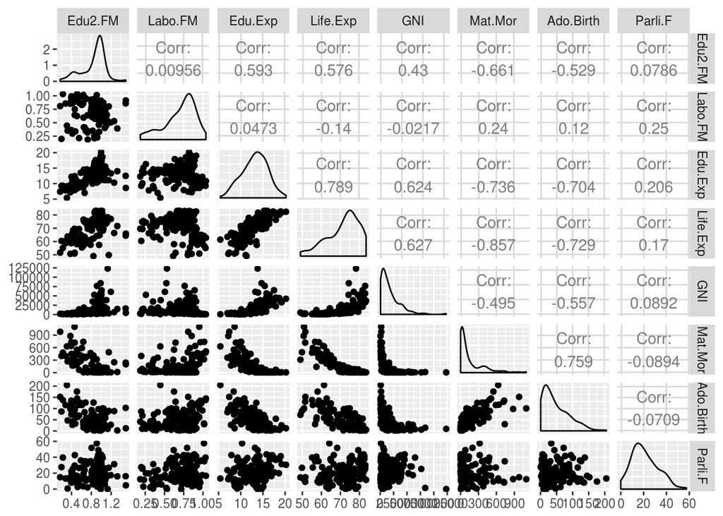

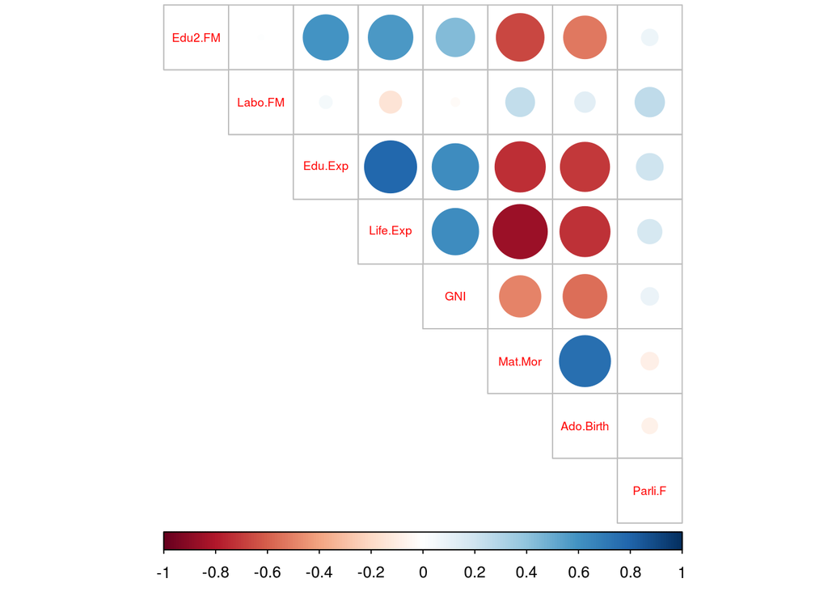

We can notice some strong correlation between several pairs of variables. Edu2.FM, Edu.Exp, Life.Exp and GNI are all negatively correlated to Mat.Mor and Ado.Birth. Labo.FM and Parli.F don’t seem to be have any correlation to the other variables. Edu.Exp and Life.Exp as well as Mat.Mor and Ado.Birth are strongly positively correlated. Edu2.FM is positively correlated to Edu.Exp, Life.Exp and GNI. GNI is also positively correlated to Life.Exp and Edu.Exp

Let us perform Principal Component Analysis on the data and then visualize the results with a biplot:

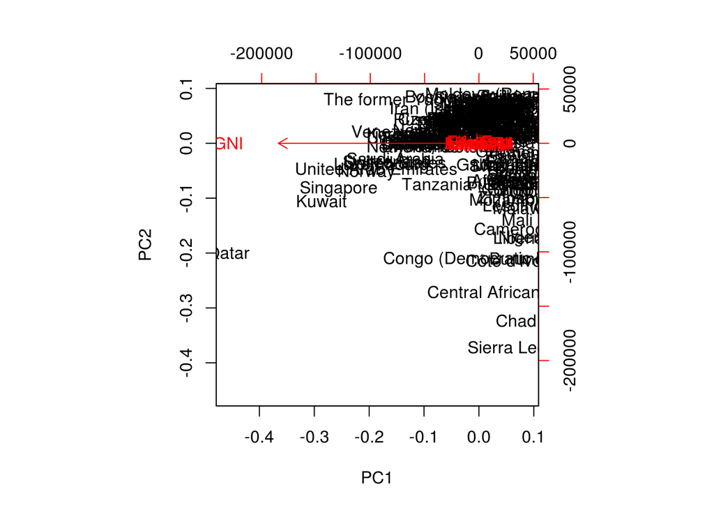

The biplot shows the arrow for GNI but the others are not visible because they have length 0. This means that GNI captures all the variance. Overall this biplot is not very informative since it doesn’t show arrows for all other variables, the plot is not centered, it is not possible to read all the countries’ names because they are either all in the same spot or out of sight in the plot.

Let us standardise the data and then perform PCA on the standardised data:

```
##     Edu2.FM           Labo.FM           Edu.Exp           Life.Exp
##  Min.   :-2.8189   Min.   :-2.6247   Min.   :-2.7378   Min.   :-2.7188
##  1st Qu.:-0.5233   1st Qu.:-0.5484   1st Qu.:-0.6782   1st Qu.:-0.6425
##  Median : 0.3503   Median : 0.2316   Median : 0.1140   Median : 0.3056
##  Mean   : 0.0000   Mean   : 0.0000   Mean   : 0.0000   Mean   : 0.0000
##  3rd Qu.: 0.5958   3rd Qu.: 0.7350   3rd Qu.: 0.7126   3rd Qu.: 0.6717
##  Max.   : 2.6646   Max.   : 1.6632   Max.   : 2.4730   Max.   : 1.4218
##       GNI             Mat.Mor          Ado.Birth          Parli.F
##  Min.   :-0.9193   Min.   :-0.6992   Min.   :-1.1325   Min.   :-1.8203
##  1st Qu.:-0.7243   1st Qu.:-0.6496   1st Qu.:-0.8394   1st Qu.:-0.7409
##  Median :-0.3013   Median :-0.4726   Median :-0.3298   Median :-0.1403
##  Mean   : 0.0000   Mean   : 0.0000   Mean   : 0.0000   Mean   : 0.0000
##  3rd Qu.: 0.3712   3rd Qu.: 0.1932   3rd Qu.: 0.6030   3rd Qu.: 0.6127
##  Max.   : 5.6890   Max.   : 4.4899   Max.   : 3.8344   Max.   : 3.1850
```

```
## Importance of components:
##                           PC1    PC2     PC3     PC4     PC5     PC6
## Standard deviation     2.0708 1.1397 0.87505 0.77886 0.66196 0.53631
## Proportion of Variance 0.5361 0.1624 0.09571 0.07583 0.05477 0.03595
## Cumulative Proportion  0.5361 0.6984 0.79413 0.86996 0.92473 0.96069
##                            PC7     PC8
## Standard deviation     0.45900 0.32224
## Proportion of Variance 0.02634 0.01298
## Cumulative Proportion  0.98702 1.00000
```

```
##  PC1  PC2  PC3  PC4  PC5  PC6  PC7  PC8
## 53.6 16.2  9.6  7.6  5.5  3.6  2.6  1.3
```

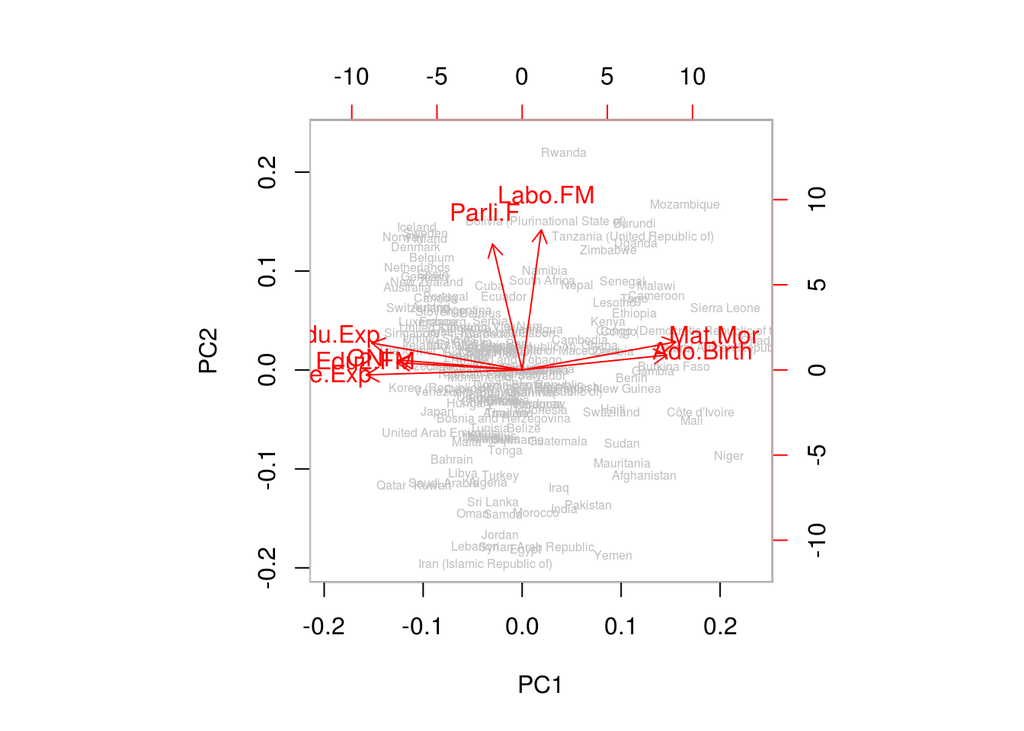

### Tea time

The tea dataset has 300 observations of 36 variables. The data was gathered by means of a questionnaire on tea consumption. The dataset contains information regarding their consumption and perception of tea, as well as some background information about the person interviewed.

```
## [1] 300  36
```

```
## 'data.frame':    300 obs. of  36 variables:
##  $ breakfast       : Factor w/ 2 levels "breakfast","Not.breakfast": 1 1 2 2 1 2 1 2 1 1 ...
##  $ tea.time        : Factor w/ 2 levels "Not.tea time",..: 1 1 2 1 1 1 2 2 2 1 ...
##  $ evening         : Factor w/ 2 levels "evening","Not.evening": 2 2 1 2 1 2 2 1 2 1 ...
##  $ lunch           : Factor w/ 2 levels "lunch","Not.lunch": 2 2 2 2 2 2 2 2 2 2 ...
##  $ dinner          : Factor w/ 2 levels "dinner","Not.dinner": 2 2 1 1 2 1 2 2 2 2 ...
##  $ always          : Factor w/ 2 levels "always","Not.always": 2 2 2 2 1 2 2 2 2 2 ...
##  $ home            : Factor w/ 2 levels "home","Not.home": 1 1 1 1 1 1 1 1 1 1 ...
##  $ work            : Factor w/ 2 levels "Not.work","work": 1 1 2 1 1 1 1 1 1 1 ...
##  $ tearoom         : Factor w/ 2 levels "Not.tearoom",..: 1 1 1 1 1 1 1 1 1 2 ...
##  $ friends         : Factor w/ 2 levels "friends","Not.friends": 2 2 1 2 2 2 1 2 2 2 ...
##  $ resto           : Factor w/ 2 levels "Not.resto","resto": 1 1 2 1 1 1 1 1 1 1 ...
##  $ pub             : Factor w/ 2 levels "Not.pub","pub": 1 1 1 1 1 1 1 1 1 1 ...
##  $ Tea             : Factor w/ 3 levels "black","Earl Grey",..: 1 1 2 2 2 2 2 1 2 1 ...
##  $ How             : Factor w/ 4 levels "alone","lemon",..: 1 3 1 1 1 1 1 3 3 1 ...
```

[output cut: 22 more lines]

```
##          breakfast           tea.time          evening          lunch
##  breakfast    :144   Not.tea time:131   evening    :103   lunch    : 44
##  Not.breakfast:156   tea time    :169   Not.evening:197   Not.lunch:256
##
##
##
##
##
##         dinner           always          home           work
##  dinner    : 21   always    :103   home    :291   Not.work:213
##  Not.dinner:279   Not.always:197   Not.home:  9   work    : 87
##
##
##
##
##
##         tearoom           friends          resto          pub
##  Not.tearoom:242   friends    :196   Not.resto:221   Not.pub:237
##  tearoom    : 58   Not.friends:104   resto    : 79   pub    : 63
##
##
##
##
##
##         Tea         How           sugar                     how
##  black    : 74   alone:195   No.sugar:155   tea bag           :170
##  Earl Grey:193   lemon: 33   sugar   :145   tea bag+unpackaged: 94
##  green    : 33   milk : 63                  unpackaged        : 36
##                  other:  9
##
##
##
##                   where                 price          age        sex
##  chain store         :192   p_branded      : 95   Min.   :15.00   F:178
##  chain store+tea shop: 78   p_cheap        :  7   1st Qu.:23.00   M:122
##  tea shop            : 30   p_private label: 21   Median :32.00
##                             p_unknown      : 12   Mean   :37.05
##                             p_upscale      : 53   3rd Qu.:48.00
##                             p_variable     :112   Max.   :90.00
##
```

[output cut: 25 more lines]

```
##  feminine    :129   Not.sophisticated: 85   No.slimming:255
##  Not.feminine:171   sophisticated    :215   slimming   : 45
##
##
##
##
##
##         exciting          relaxing              effect.on.health
##  exciting   :116   No.relaxing:113   effect on health   : 66
##  No.exciting:184   relaxing   :187   No.effect on health:234
##
##
##
##
##
```

Let us visualize the dataset:

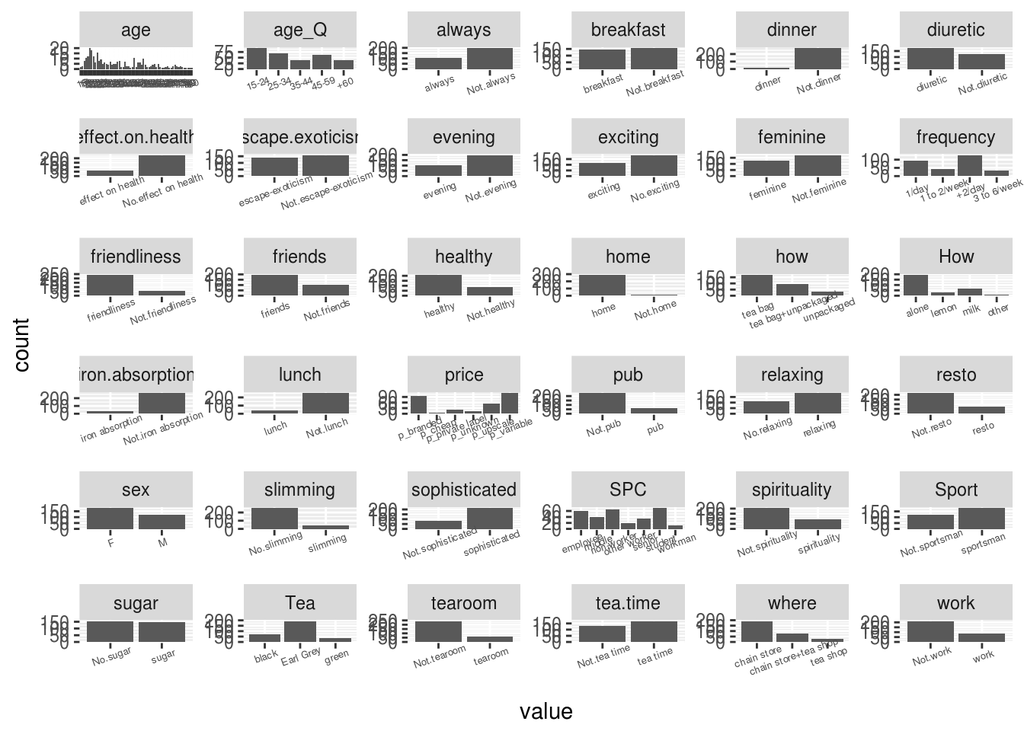

Now let us choose some of the variables in the dataset and perform Multiple Correspondence Analysis:

```
##
## Call:
## MCA(X = tea, graph = FALSE)
##
##
## Eigenvalues
##                        Dim.1   Dim.2   Dim.3   Dim.4   Dim.5   Dim.6
## Variance               0.345   0.290   0.282   0.258   0.245   0.230
## % of var.             15.329  12.898  12.555  11.446  10.889  10.240
## Cumulative % of var.  15.329  28.227  40.783  52.228  63.117  73.357
##                        Dim.7   Dim.8   Dim.9
## Variance               0.226   0.209   0.164
## % of var.             10.065   9.301   7.278
## Cumulative % of var.  83.421  92.722 100.000
##
## Individuals (the 10 first)
##              Dim.1    ctr   cos2    Dim.2    ctr   cos2    Dim.3    ctr
## 1         |  0.033  0.001  0.001 |  0.107  0.013  0.007 | -0.226  0.060
## 2         |  0.582  0.328  0.137 |  0.133  0.020  0.007 | -1.056  1.317
## 3         |  0.353  0.120  0.147 | -0.280  0.090  0.093 |  0.224  0.059
## 4         | -0.636  0.391  0.375 | -0.186  0.040  0.032 | -0.143  0.024
## 5         |  0.353  0.120  0.147 | -0.280  0.090  0.093 |  0.224  0.059
## 6         | -0.048  0.002  0.002 | -0.493  0.279  0.232 | -0.095  0.011
## 7         |  0.083  0.007  0.003 | -0.241  0.067  0.024 |  1.081  1.378
## 8         |  0.468  0.212  0.065 |  0.518  0.308  0.079 | -0.590  0.411
## 9         |  0.314  0.095  0.059 |  0.053  0.003  0.002 | -0.655  0.506
## 10        |  1.022  1.009  0.709 |  0.013  0.000  0.000 |  0.141  0.024
##             cos2
## 1          0.030 |
## 2          0.451 |
## 3          0.059 |
## 4          0.019 |
## 5          0.059 |
## 6          0.009 |
## 7          0.474 |
## 8          0.103 |
## 9          0.259 |
## 10         0.014 |
##
## Categories (the 10 first)
```

[output cut: 14 more lines]

```
## green     -10.844 |  -0.186   0.337   0.004  -1.130 |
## alone      -9.673 |   0.393   8.863   0.286   9.250 |
## lemon       6.320 |   0.483   2.272   0.029   2.937 |
## milk        2.742 |  -1.476  40.480   0.579 -13.158 |
## other       8.908 |   0.055   0.008   0.000   0.166 |
## No.sugar   -5.722 |   0.050   0.113   0.003   0.890 |
## sugar       5.722 |  -0.053   0.121   0.003  -0.890 |
## 1/day      -4.444 |  -0.716  14.347   0.237  -8.422 |
##
## Categorical variables (eta2)
##             Dim.1 Dim.2 Dim.3
## Tea       | 0.443 0.465 0.010 |
## How       | 0.219 0.506 0.583 |
## sugar     | 0.477 0.110 0.003 |
## frequency | 0.241 0.081 0.534 |
```

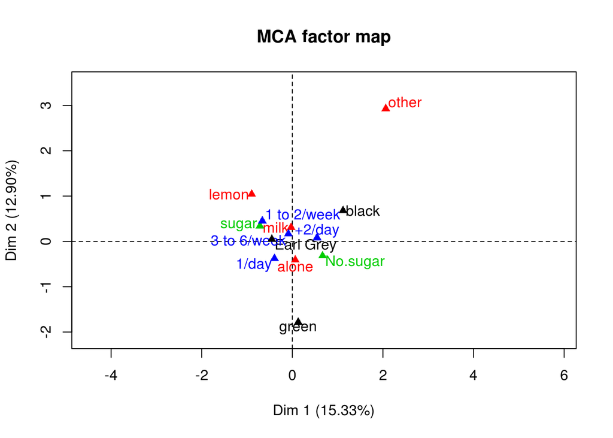